# Introduction à la modélisation statistique bayésienne

Ladislas Nalborczyk & Thierry Phénix

### Planning

## Cours

Cours 1: Introduction à l'inférence bayésienne

**Cours 2: Modèle beta-binomial**

Cours 3 & 4: Modèle de régression linéaire

Cours 5: Markov Chain Monte Carlo

Cours 6: Modèle linéaire généralisé

Cours 7: Comparaison de modèles

Cours 8: Modèles multi-niveaux

Cours 9: Introduction à `brms`

Cours 10: Data Hackaton

## Plan

- **Rappels et objectifs**
- Définition du modèle
- La distribution postérieure
- Utilisation du modèle

### Rappels

### PRINCIPES DE L'ANALYSE DE DONNÉES BAYÉSIENNE

- Un ensemble de données / mesures **observées** à analyser :  
  \( y_1, y_2, \dots, y_N \)
- Un modèle génératif défini par un ensemble de paramètres  
  \( \theta_1, \theta_2, \dots, \theta_K \)
- Une connaissance **a priori** de ces paramètres

**Nous cherchons**

> The first idea is that Bayesian inference is **reallocation of credibility across possibilities**.

> The second foundational idea is that the **possibilities**, over which we allocate credibility, **are parameter values** in meaningful mathematical models.

> *Kruschke (2015)*

### Rappels

### UTILISATION DE LA RÈGLE DE BAYES

Ces observations et ces paramètres sont regroupés dans un même modèle bayésien :

**la distribution conjointe \( P(y_1, y_2, \dots, y_N,\theta_1, \theta_2, \dots, \theta_K)~ \)** que l'on note **\( ~P(y_{1:N}~\theta_{1:K}) \)**

### Application du théorème de Bayes :

- En faisant apparaître la fonction de vraissemblance (**likelihood**) et la distribution a priori (**prior**)

> \[ P(y_{1:N}~\theta_{1:K})~=~\color{orangered}{P(y_{1:N}~|~\theta_{1:K})}~\color{steelblue}{P(\theta_{1:K})} \]
- En faisant apparaître la distribution postérieure

> \[ P(y_{1:N}~\theta_{1:K})~=~\color{purple}{P(\theta_{1:K}~|~y_{1:N})}~\color{green}{P(y_{1:N})} \]

### Rappels

### INFÉRENCE BAYESIENNE

On infére les nouvelles valeurs des paramètres à partir des données

> \[ \color{purple}{P(\theta_{1:K}~|~y_{1:N})} = \frac{\color{orangered}{P(y_{1:N}~|~\theta_{1:K})}~\color{steelblue}{P(\theta_{1:K})}}{\color{green}{P(y_{1:N})}} \]

> Ou encore

> \[ \color{purple}{P(\theta_{1:K}~|~y_{1:N})} \propto \color{orangered}{P(y_{1:N}~|~\theta_{1:K})}~\color{steelblue}{P(\theta_{1:K})} \]

### L'objectif de l'analyse de données bayésienne

> Faire évoluer une connaissance a priori sur les paramètres \( ~\color{steelblue}{P(\theta_{1:K})} \)  
> En une connaissance à postériori \( ~\color{purple}{P(\theta_{1:K}~|~y_{1:N})} \)  
> En intégrant les nouvelles données \( ~\color{orangered}{P(y_{1:N}~|~\theta_{1:K})} \)

### Rappels

### LES ETAPES DE L'ANALYSE DE DONNÉES BAYÉSIENNE

**1. Définir le modèle**

- Identifier les paramètres du modèle génératif (**Likelihood**)
- Définir une distribution a priori (**prior**)

**2. Mettre à jour le modèle**

- Calculer la distribution a posteriori des paramètres (ou une bonne approximation)

**3. Interpréter la distribution postérieure (répondre à la question posée)**

- Estimation des paramètres
- Comparaison de modèles
- Vérification des prédictions du modèle

### Objectifs de ce cours

## Illustrer les différents aspects de cette démarche

## à l'aide d'un modèle simple

## le modèle Beta-Binomial

### Planning

## Cours

Cours 1: Introduction à l'inférence bayésienne

**Cours 2: Modèle beta-binomial**

Cours 3 & 4: Modèle de régression linéaire

Cours 5: Markov Chain Monte Carlo

Cours 6: Modèle linéaire généralisé

Cours 7: Comparaison de modèles

Cours 8: Modèles multi-niveaux

Cours 9: Introduction à `brms`

Cours 10: Data Hackaton

## Plan

- Rappels et objectifs
- **Définition du modèle**
  - **Likelihood**
  - **Prior**
- La distribution postérieure
- Utilisation du modèle

### Le modèle beta-binomial

### POURQUOI COMMENCER PAR CE MODÈLE

### Le modèle beta-binomial couvre un grand nombre de problèmes de la vie courante :

- - Réussite / Echec à un test psychométrique ?
  - Présence / absence d'effets secondaires lors d'un test d'un médicament ?
  - Résultat d'un questionnaire à réponse binaire vrai/faux
  - Estimation des résultats du deuxième tour de l'éléction présidentielle
  - …

### C'est un modèle simple

- - Un unique paramètre
  - Solution analytique

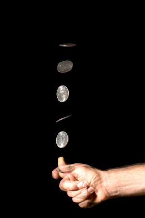

### Définition du modèle

### LIKELIHOOD

**Modèle d'un lancer unique**

[figure not shown]

Jacques ou Jakob Bernoulli (1654-1705)  
mathématicien et physicien suisse  
(né et mort à Bâle)

Depuis Bernoulli, on sait calculer la probabilité du résultat d'un lancer, du moment que l'on connait le biais de la pièce

### \[ P(Y=y~|~\theta)=\theta^y~(1-\theta)^{(1-y)} \]

> avec \( ~\theta~ \) la probabilité de l'évènement, le résultat du lancer est \( \textit{'Face'} \)

**Modèle d'une suite de lancers (processus de Bernoulli)**

Pour une série de lancers \( \{Y_i\} \) indépendants et identiquement distribués (i.i.d.)

### \[ P(\{Y_i=y_i\}~|~\theta)=\theta^z~(1-\theta)^{(N-z)} \]

> avec \( ~z=\sum_i y_i~ \) le nombre de \( \textit{'Face'} \) et N nombre d'observations

### Définition du modèle - Les données

- Génération des données avec un processus de Bernouilli, \( ~\theta = 0.6~ \).

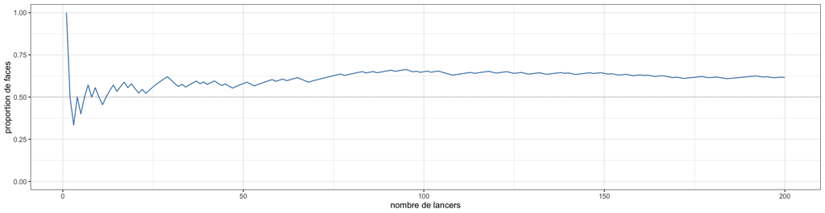

```r
library(tidyverse)
set.seed(1234567)
n_draws <- 200
data <- tibble(
    draws    = rbinom(n_draws, size = 1, prob = .6)) %>%
    mutate(x = 1:n()) %>%
    mutate(y = cumsum(draws) / x)
data %>%
    ggplot(aes(x = x, y = y), log = "y") +  geom_line(lwd = 1, col = "steelBlue") +
    geom_hline(yintercept = 0.5, lty = 3) +
    xlab("nombre de lancers") + ylab("proportion de faces") +
    ylim(0, 1) + theme_bw(base_size = 20)
```

### Définition du modèle

### LIKELIHOOD

- Nous considérons \( z \) comme étant le nombre de succès \( \{y_i\} \)
- Nous considérons le nombre d'observations N comme étant une **constante**
- Nous considérons \( ~\theta~ \) comme étant le **paramètre** de notre modèle

**La fonction de likelihood s'écrit :**

### \[ \color{orangered}{L(\theta~|~z~N)=P(z~|~\theta~N)=\theta^z~(1-\theta)^{(N-z)}} \]

> **ATTENTION !!!** Ici, c'est une fonction de \( ~\theta \)

### Définition du modèle

### LIKELIHOOD - distribution Binomiale

Représentation graphique de la fonction de vraissemblance de \( \theta \) pour 10 lancers et 7 *Faces*

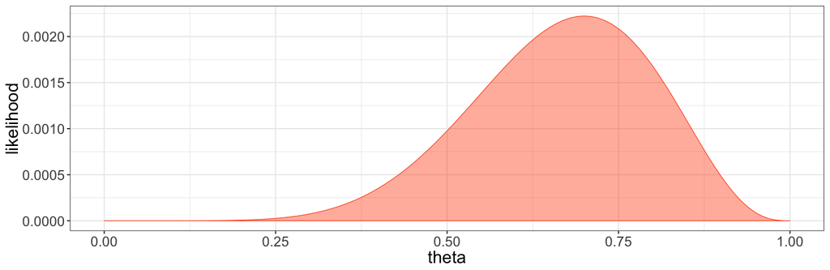

```r
NbrTrial     = 100
N            = 10
nbrSuccess   = 7
samples <- tibble(
    theta               = seq(from = 0, to = 1, by = 1/NbrTrial)) %>%
    mutate(likelihood   = (theta^(nbrSuccess)) * (1 - theta)^(N - nbrSuccess) )

samples %>%
    ggplot(aes(x = theta, y = likelihood)) +
    geom_area(color="orangered", fill = "orangered", alpha =.4) +
    theme_bw(base_size = 20) + theme(legend.position="none",
          text = element_text(size=30))
```

### Définition du modèle

### PRIOR

### Comment définir un prior dans le cas du lancer de pièce ?

**Aspect sémantique** \( ~\rightarrow~ \) *doit pouvoir rendre compte d'* :

- Une absence d'information
- Une connaissance d'observations antérieures concernant la pièce étudiée
- Un niveau de certitude concernant ces observations antérieures

**Aspect mathématique** \( ~\rightarrow~ \) *pour une solution entièrement analytique* :

- Les distribution postérieure et prior doivent avoir la même forme
- La vraissemblance marginale doit se calculer analytiquement

### Définition du modèle

### PRIOR - distribution Beta

### La distribution beta:

> \[ \begin{align} \color{steelblue}{p(\theta~|~a,b)} &= beta(\theta~|~a,b) \\ &= \theta^{(a-1)}(1-\theta)^{(b-1)}/B(a,b) \\ &\propto \theta^{(a-1)}(1-\theta)^{(b-1)} \end{align} \]

> où \( a \) et \( b \) sont deux paramètres tels que \( ~a\geq0~et~b\geq0~ \) et \( ~B(a,b)~ \) est une constante de normalisation

Attention : Ne pas confondre dans R : la fonction de \( ~\theta~ \) et la constante (indépendante de \( ~\theta~ \))

```r
a     = 2
b     = 3
theta = seq( from= 0 , to= 1 , length.out= 7 )
dbeta(theta,a,b)
```

```
[1] 0.0000000 1.3888889 1.7777778 1.5000000 0.8888889 0.2777778 0.0000000
```

```r
beta(a,b)
```

```
[1] 0.08333333
```

### Définition du modèle

### PRIOR - distribution Beta

**Vérifions les contraintes mathématiques**

> Le résultat du produit d'une distribution beta et d'une fonction de vraissemblance binomiale est proportionnel à une distribution beta.  
> On dit que la distribution beta est **la distribution conjugée** de la fonction de vraissemblance binomiale

Soit un prior définit par \( ~~~\color{steelblue}{p(\theta~|~a,b) \propto \theta^{(a-1)}(1-\theta)^{(b-1)}} \)  
Soit une fonction de vraissemblance associée à z “Face” pour N lancers \( ~~\color{orangered}{P(\{y_i\}~|~\theta)=\theta^z~(1-\theta)^{(N-z)}} \)

\[ \begin{align} \color{purple}{p(\theta~|~\{y_i\})} &\propto \color{orangered}{P(\{y_i\}~|~\theta)}~\color{steelblue}{p(\theta~|~a,b)} &&\mbox{inférence Bayésienne} \\ &\propto \color{orangered}{\theta^z~(1-\theta)^{(N-z)}}~\color{steelblue}{\theta^{(a-1)}(1-\theta)^{(b-1)}} &&\mbox{application des formules précédentes} \\ &\propto \color{purple}{\theta^{(z+a-1)}~(1-\theta)^{(N-z+b-1)}} &&\mbox{en regroupant les termes identiques} \\ &\propto \color{purple}{\theta^{(A-1)}(1-\theta)^{(B-1)}} &&\mbox{avec } A=z+a \mbox{ et } B=N-z+b \end{align} \]

**Conclusions : la distribution a priori et la distribution a posteriori ont la même forme**

### Définition du modèle

### PRIOR - distribution Beta

**Vérifions les aspects sémantiques**

> Soit un prior définit par \( ~~~\color{steelblue}{p(\theta~|~a,b) \propto \theta^{(a-1)}(1-\theta)^{(b-1)}} \)
- On peut exprimer l'absence de connaissance à priori - a=1 et b=1 (courbe bleue).
- On modélise un biais en faveur de *Face* - a > b (courbe verte).
- On modélise un biais en faveur de *Pile* - a < b (courbe orange).

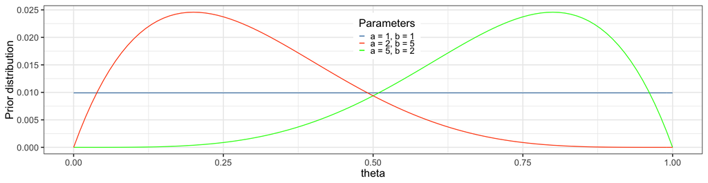

### Définition du modèle

### PRIOR - distribution Beta

**Vérifions les aspects sémantiques**

- Le niveau de certitude augmente avec la somme (\( \kappa = a+b \))
  - Aucune idée sur la provenance de la pièce : a = b = 1 -> **prior faible** (courbe bleue)
  - En attendant le début de l'expérience, on a lancé la pièce 10 fois pour 5 *“Face”* : a = b = 5 (courbe orange)
  - La pièce provient de la banque de France : a = b = 50 -> **prior fort** (courbe verte)

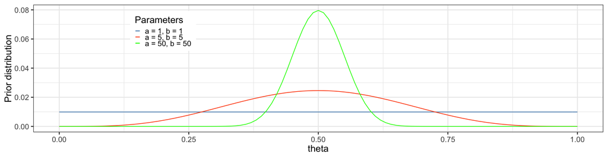

### Définition du modèle

### PRIOR - distribution Beta

Le plus souvent, on dispose :

- D'information sur la tendance centrale du paramètre (mode, moyenne)
- D'un niveau de certitude ( \( \kappa = a+b \) )

### Définition du modèle

### PRIOR - distribution Beta

**Le mode**  
Supposons que l'on ait une estimation de la valeur la plus probable \( \omega \) du paramètre \( \theta \)  
On peut définir les paramètres a et b de notre prior

> \[ \begin{align} a &= \omega(\kappa-2)+1 \\ b &= (1-\omega)(\kappa-2)+1 &&\mbox{pour } \kappa>2 \end{align} \]

Pour \( ~~\omega=0.65~ \) et \( ~\kappa=25 \) alors \( ~p(\theta)=beta(\theta~|~15.95, 9.05)~ \) (courbe orange)  
Pour \( ~~\omega=0.65~ \) et \( ~\kappa=10 \) alors \( ~p(\theta)=beta(\theta~|~6.2, 3.8)~ \) (courbe bleue)

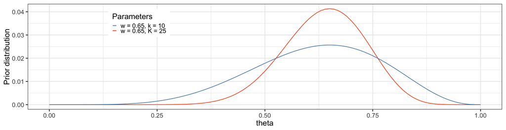

### Définition du modèle

### PRIOR - distribution Beta

**La moyenne**  
Supposons que l'on ait une estimation de la valeur moyenne \( \mu \) du paramètre \( \theta \)  
On peut définir les paramètres a et b de notre prior

> \[ \begin{align} a &= \mu \kappa \\ b &= (1-\mu) \kappa &&\mbox{ pour } \kappa>2 \end{align} \]

Pour \( \mu=0.8~ \) et \( ~\kappa=7~ \) alors \( ~p(\theta)=beta(\theta~|~5.6,1.4) \) (courbe orange)  
Pour \( \mu=0.8~ \) et \( ~\kappa=22~ \) alors \( ~p(\theta)=beta(\theta~|~17.6,4.4) \) (courbe bleue)

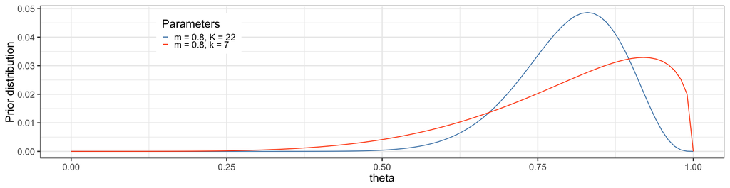

### Définition du modèle

### PRIOR - distribution Beta

**La moyenne et la variance**  
Supposons que l'on ait une estimation a priori de la valeur moyenne \( \mu \) et de la variance \( \sigma \) du paramètre \( \theta \)  
On peut définir les paramètres a et b de notre prior

> \[ \begin{align} a &= \mu~(\mu~(1-\mu)~/~\sigma^2-1) \\ b &= (1-\mu)~\mu~(\mu~(1-\mu)~/~\sigma^2-1) ,~~~~~ \mbox{ pour } \sigma < 0.28867 \\ \end{align} \]

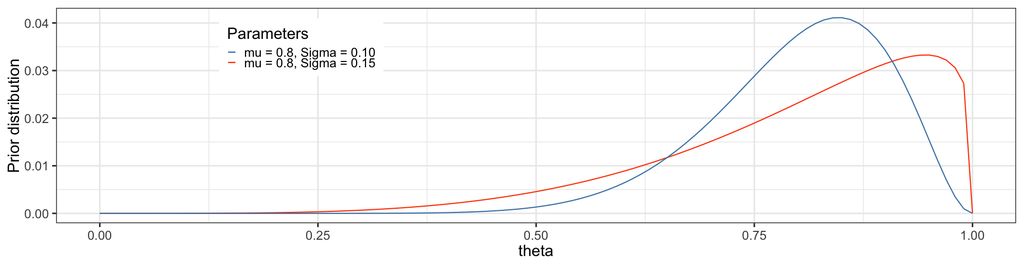

### Définition du modèle

### PRIOR - Influence du prior sur la distribution postérieure

**Cas \( ~N < a+b \)** \( ~(~N=10, ~a=4, ~b=16~) \)

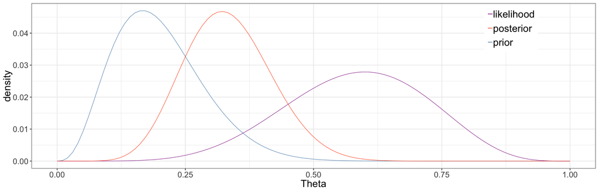

### Définition du modèle

### PRIOR - Influence du prior sur la distribution postérieure

**Cas \( ~N = a+b \)** \( ~(~N=20, ~a=4, ~b=16~) \)

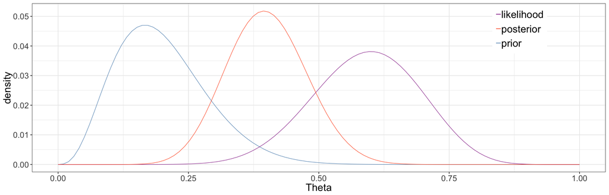

### Définition du modèle

### PRIOR - Influence du prior sur la distribution postérieure

**Cas \( ~N > a+b \)** \( ~(~N=40, ~a=4, ~b=16~) \)

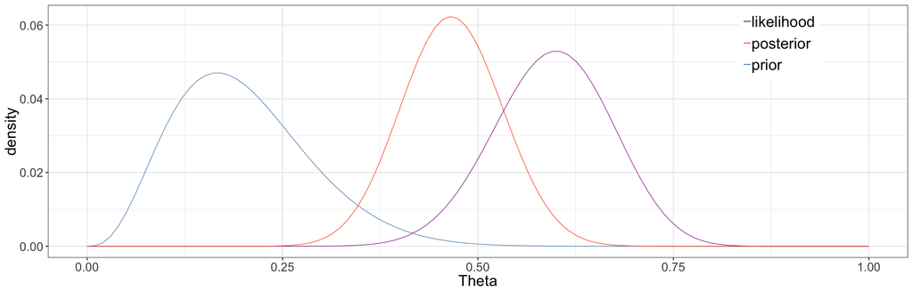

### Définition du modèle

### CONCLUSION

> There are two main desiderata for a mathematical description of data.
> - First, the mathematical form should be comprehensible with meaningful parameters.
> - Second, the mathematical description should be descriptively adequate, which means, loosely, that the mathematical form should “look like” the data.

> *Kruschke (2015)*

### Planning

## Cours

Cours 1 : Introduction à l'inférence bayésienne

**Cours 2 : Modèle beta-binomial**

Cours 3 & 4 : Modèle de régression linéaire

Cours 5 : Markov Chain Monte Carlo

Cours 6 : Modèle linéaire généralisé

Cours 7 : Comparaison de modèles

Cours 8 : Modèles multi-niveaux

Cours 9 : Introduction à `brms`

Cours 10 : Data Hackaton

## Plan

- Rappels et objectifs
- Définition du modèle
- **La distribution postérieure**
  - **Cas analytique**
  - **Méthode Grid**
  - **Le modèle binomial**
- Utilisation du modèle

### La distribution postérieure

### INTRODUCTION

> The posterior distribution is always a compromise between the prior distribution and the likelihood function.  
> *Kruschke (2015)*

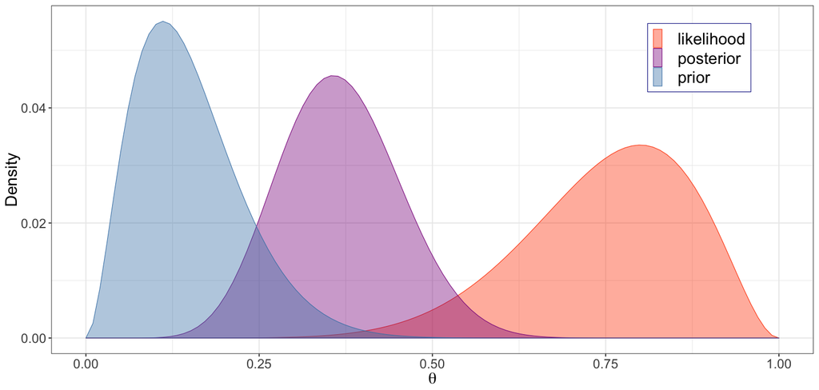

### La distribution postérieure

### PRINCIPE

> \[ Posterior = \frac{Likelihood~\times~Prior}{\color{orangered}{Marginal~Likelhood}} \]

### PROBLÈME :

le calcul de la “marginal likelihood”, \( \color{green}{~p(D)} \)

\[ \begin{align} \color{green}{p(D)} &= \int P(D,\theta) \, \mathrm d\theta &&\mbox{marginalisation sur le paramètre} \theta \\ \color{green}{p(D)} &= \color{green}{\int P(D~|~\theta)~P(\theta) \, \mathrm d\theta} && \mbox{Application de la règle du produit} \end{align} \]

Dans la littérature, on le trouve sous le nom de : “evidence”, “probabilité des données” ou **“Marginal Likelihood”**

### La distribution postérieure

### PRINCIPE

> \[ Posterior = \frac{Likelihood~\times~Prior}{\color{orangered}{Marginal~Likelhood}} \]

### Trois méthodes pour résoudre ce problème :

> 1. Solution analytique \( ~~\longrightarrow~~ \) Utilisation d'une likelihood conjuguée du prior
> 2. Solution discrètisée \( ~~\longrightarrow~~ \) Calcul de la solution sur un ensemble fini de points (Méthode Grid)
> 3. Solution approchée \( ~~\longrightarrow~~ \) On échantillonne “intelligemment” sur l'espace conjoint des paramètres (Méthode MCMC)

### La distribution postérieure

### CAS ANALYTIQUE

Utilisation d'une likelihood conjuguée du prior : cas Beta-binomiale

\[ \begin{align} \color{purple}{p(\theta~|~z,N)} &= \color{orangered}{P(z~|~\theta,N)}~\color{steelblue}{p(\theta)/\color{green}{P(z~|~N)}} &&\mbox{Équation de Bayes} \\ &= \color{orangered}{\theta^z~(1-\theta)^{(N-z)}}~\color{steelblue}{\frac{\theta^{(a-1)}(1-\theta)^{(b-1)}}{B(a,b)}}/\color{green}{P(z~|~N)} &&\mbox{Application des formules précédetes} \\ &= \frac{\color{orangered}{\theta^z~(1-\theta)^{(N-z)}}~\color{steelblue}{\theta^{(a-1)}(1-\theta)^{(b-1)}}}{\color{steelblue}{B(a,b)}\color{green}{P(z~|~N)}} \\ &= \frac{\theta^{(\color{orangered}{z}+\color{steelblue}{a-1})}~(1-\theta)^{(\color{orangered}{N-z}+\color{steelblue}{b-1})}}{\color{steelblue}{B(a,b)}\color{green}{P(z~|~N)}} &&\mbox{En regroupant les termes identiques} \\ &= \frac{\theta^{(\color{orangered}{z}+\color{steelblue}{a-1})}~(1-\theta)^{(\color{orangered}{N-z}+\color{steelblue}{b-1})}}{B(\color{orangered}{z}+\color{steelblue}{a},\color{orangered}{N-z}+\color{steelblue}{b})} &&\mbox{Par identification à une fonction beta} \\ \end{align} \]

> L'avantage d'avoir un prior conjugué nous dispense du calcul du dénominateur

### La distribution postérieure

### CAS ANALYTIQUE

**Distributions discrètes**

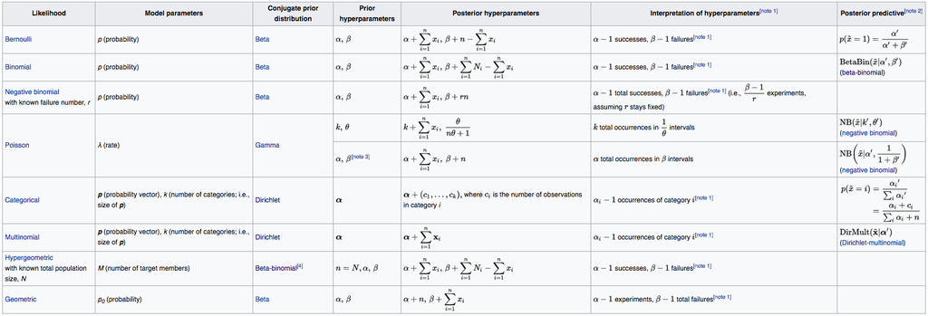

### La distribution postérieure

### CAS ANALYTIQUE

**Distributions continues**

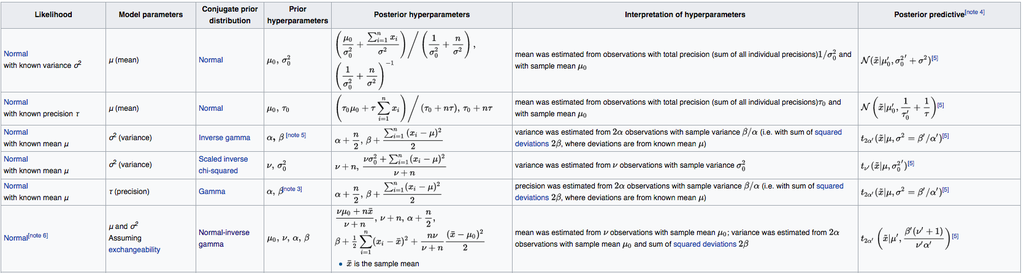

> **TROP CONTRAIGNANT !!!**

Le modèle (likelihood + prior) doit être défini à partir de l'interprétation que l'on peut faire des paramètres et des distributions  
et non pour faciliter les calculs

### La distribution postérieure

### MÉTHODE GRID

1. **Définir la grille**
2. Calculer la valeur du prior pour chaque valeur de la grille
3. Calculer la valeur de la likelihood pour chaque valeur de la grille
4. Calculer le produit prior x likelihood pour chaque valeur de la grille, puis normalisation du résultat

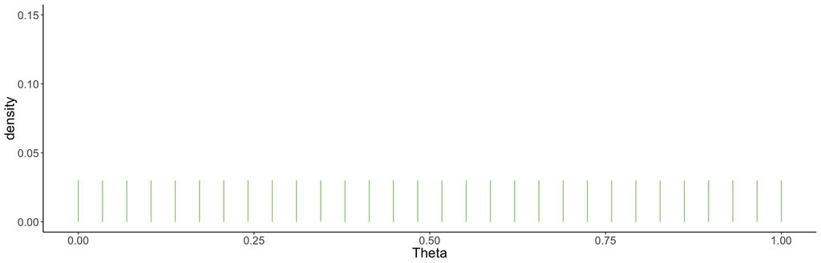

### La distribution postérieure

### MÉTHODE GRID

1. Définir la grille
2. **Calculer la valeur du prior pour chaque valeur de la grille**
3. Calculer la valeur de la likelihood pour chaque valeur de la grille
4. Calculer le produit prior x likelihood pour chaque valeur de la grille, puis normalisation du résultat

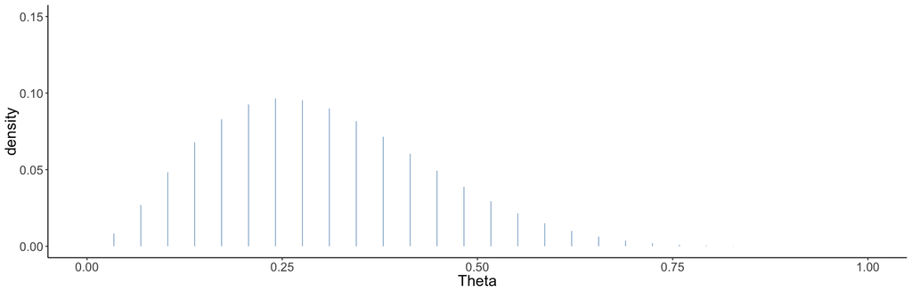

### La distribution postérieure

### MÉTHODE GRID

1. Définir la grille
2. Calculer la valeur du prior pour chaque valeur de la grille
3. **Calculer la valeur de la likelihood pour chaque valeur de la grille**
4. Calculer le produit prior x likelihood pour chaque valeur de la grille, puis normalisation du résultat

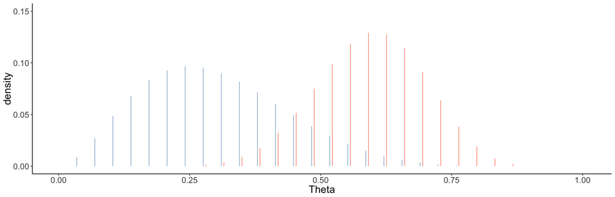

### La distribution postérieure

### MÉTHODE GRID

1. Définir la grille
2. Calculer la valeur du prior pour chaque valeur de la grille
3. Calculer la valeur de la likelihood pour chaque valeur de la grille
4. **Calculer le produit prior x likelihood pour chaque valeur de la grille, puis normalisation du résultat**

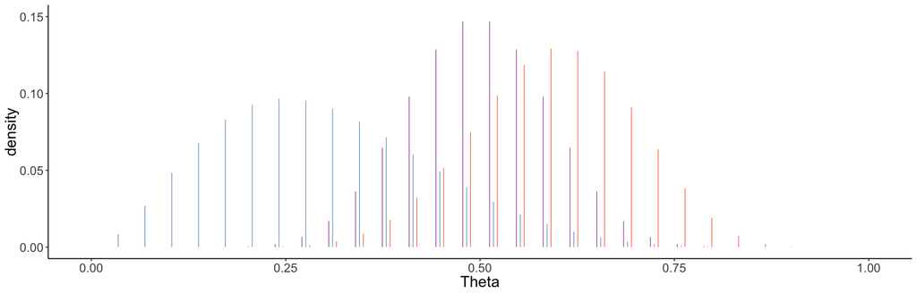

### La distribution postérieure

### MÉTHODE GRID - grille affinée

1. Définir la grille
2. Calculer la valeur du prior pour chaque valeur de la grille
3. Calculer la valeur de la likelihood pour chaque valeur de la grille
4. **Calculer le produit prior x likelihood pour chaque valeur de la grille, puis normalisation du résultat**

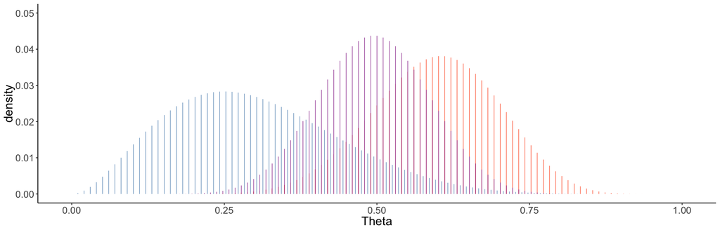

### La distribution postérieure

### MÉTHODE GRID - Problème du nombre de paramètres

[figure not shown]